# Data Visualisation

Robin Lovelace University of Leeds, 2020-02-26

[figure not shown]

## Review of homework exercise: demo then individual Q&A

```r
library(tidyverse)
library(stplanr)
library(sf)
```

## Basics of data visualisation

Data visualisation is a powerful way to help understand and communicate insights about the real world contained in data.

Take this dataset:

```r
crashes_gb = stats19::get_stats19(year = 2018, type = "accidents")
```

```
## Files identified: dftRoadSafetyData_Accidents_2018.csv

##    http://data.dft.gov.uk.s3.amazonaws.com/road-accidents-safety-data/dftRoadSafetyData_Accidents_2018.csv

## Data already exists in data_dir, not downloading

## Data saved at ~/stats19-data/dftRoadSafetyData_Accidents_2018.csv

## Reading in:

## ~/stats19-data/dftRoadSafetyData_Accidents_2018.csv

## date and time columns present, creating formatted datetime column
```

```r
crashes_gb
```

```
## # A tibble: 122,635 x 33
##    accident_index location_eastin… location_northi… longitude latitude police_force
##    <chr>                     <int>            <int>     <dbl>    <dbl> <chr>
##  1 2018010080971            529150           182270   -0.140      51.5 Metropolita…
##  2 2018010080973            542020           184290    0.0465     51.5 Metropolita…
##  3 2018010080974            531720           182910   -0.102      51.5 Metropolita…
##  4 2018010080981            541450           183220    0.0378     51.5 Metropolita…
##  5 2018010080982            543580           176500    0.0658     51.5 Metropolita…
##  6 2018010080983            526060           194910   -0.180      51.6 Metropolita…
##  7 2018010080986            525050           181050   -0.199      51.5 Metropolita…
##  8 2018010080987            536710           176960   -0.0329     51.5 Metropolita…
##  9 2018010080990            517110           186280   -0.312      51.6 Metropolita…
## 10 2018010080992            535450           181190   -0.0494     51.5 Metropolita…
## # … with 122,625 more rows, and 27 more variables: accident_severity <chr>,
## #   number_of_vehicles <int>, number_of_casualties <int>, date <date>, day_of_week <chr>,
## #   time <chr>, local_authority_district <chr>, local_authority_highway <chr>,
## #   first_road_class <chr>, first_road_number <int>, road_type <chr>, speed_limit <int>,
## #   junction_detail <chr>, junction_control <chr>, second_road_class <chr>,
## #   second_road_number <int>, pedestrian_crossing_human_control <chr>,
## #   pedestrian_crossing_physical_facilities <chr>, light_conditions <chr>,
## #   weather_conditions <chr>, road_surface_conditions <chr>,
## #   special_conditions_at_site <chr>, carriageway_hazards <chr>,
## #   urban_or_rural_area <chr>, did_police_officer_attend_scene_of_accident <int>,
## #   lsoa_of_accident_location <chr>, datetime <dttm>
```

Without some kind of analysis, it is hard to understand the meaning of the data. Descriptive statistics can help, e.g. on the percentage of different crashes that happened by speed limit:

```r
count_table = table(crashes_gb$speed_limit, crashes_gb$accident_severity)
count_table
```

```
##
##      Fatal Serious Slight
##   20    49    1734   8878
##   30   567   13009  59903
##   40   169    2104   7956
##   50   139    1017   3897
##   60   542    3950  10895
##   70   205    1351   6270
```

```r
count_table_proportions = count_table / rowSums(count_table)
round(count_table_proportions * 100, 1)
```

```
##
##      Fatal Serious Slight
##   20   0.5    16.3   83.3
##   30   0.8    17.7   81.5
##   40   1.7    20.6   77.8
##   50   2.8    20.1   77.1
##   60   3.5    25.7   70.8
##   70   2.6    17.3   80.1
```

As expected, crashes that happened on roads with a higher speed limit have a higher fatality rate. This can be visualised in a more appealing and intuitive way, e.g. as follows:

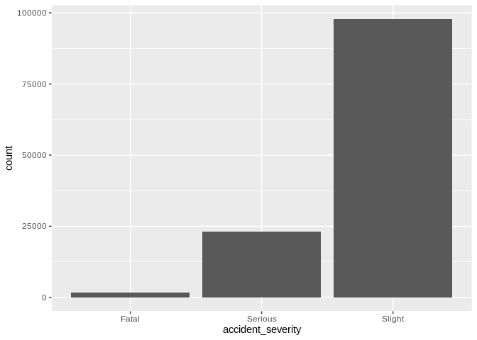

```r
library(ggplot2)
ggplot(crashes_gb) + geom_bar(aes(accident_severity))
```

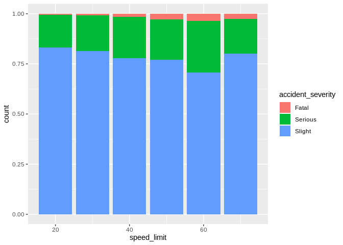

```r
ggplot(crashes_gb, aes(speed_limit)) + geom_bar(aes(fill = accident_severity), position = "fill")
```

**Exercise**: Read the documentation that appears when you run this line of code:

```
?facet_grid
```

Create a facetted plot with a different facet for each speed limit.

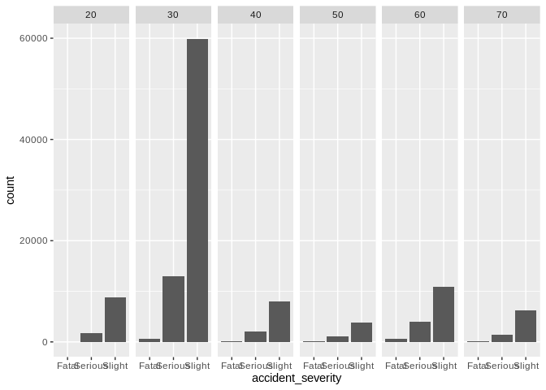

## Result: base graphics

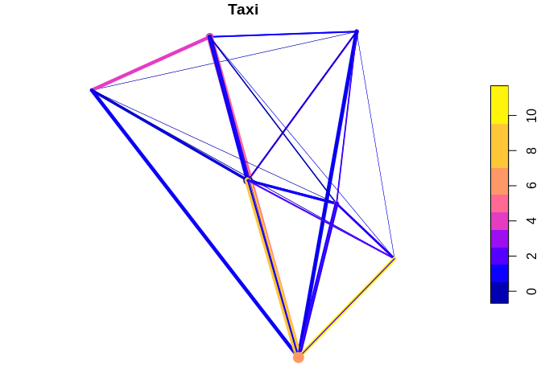

## Result: tmap

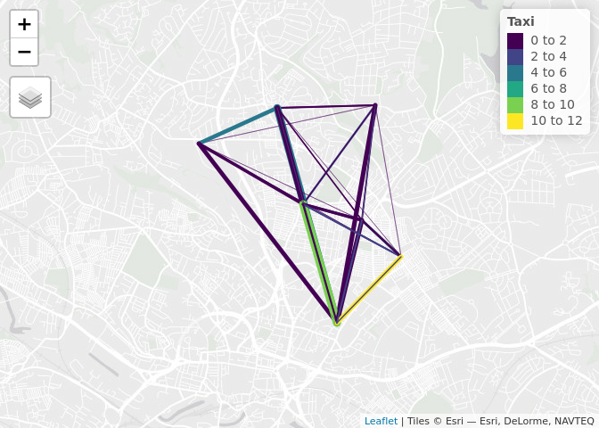

## Exercises: Individual

- Based on the `routes_fast_sf` data in the `stplanr` package, identify roads where investment in cycling is likely to be effective.

Starting point:

```r
nrow(flowlines_sf)
```

```
## [1] 49
```

```r
nrow(routes_fast_sf)
```

```
## [1] 49
```

```r
# routes_fast_sf = dplyr::inner_join(routes_fast_sf, flow)
routes_fast_sf = cbind(routes_fast_sf, flowlines_sf)
```

## sf results

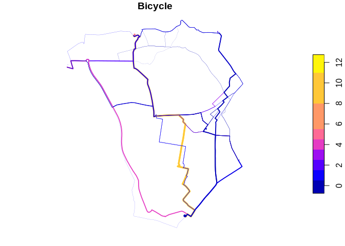

## tmap ‘view mode’ results

[figure not shown]

## Exercises bonus (optional)

- Work through the PCT training vignette at: https://itsleeds.github.io/pct/articles/pct_training.html
- Using data in the `pct` github package, estimate cycling potential in a city of your choice in the UK, and show the results.

## Homework

- To improve you R skills, work through the stats19 tutorial here: https://docs.ropensci.org/stats19/articles/stats19-training.html
- Work on your portfolios, adding a new visualisation of the data you will use